# Data Analyses Script (script 2)for the project, Association Between CAIDE Risk Score and Episodic Memory in Middle-Aged Females: The Impact of Natural Menopause

Julia Kearley, McGill University

2025-04-16

> **Note:** This script is for the data analyses (Script 2) to the manuscript:

> *Kearley, J. et al. (2025). Association Between CAIDE Risk Score and Episodic Memory in Middle-Aged Females: The Impact of Natural Menopause.*

## 0.1 Reproducibility Requirements

- **R version:** 4.3 or later
- **Required R packages:** (see full list below)
- **Data:** Cleaned dataset generated from `Kearley_bhamm_CAIDE_script1.rmd`

## 0.2 Analysis Overview

### 0.2.1 Part III: Descriptives: CAIDE Risk Score **(Figure 4)**

- Descriptive statistics
- Visualizations

### 0.2.2 Part IV: Main Analyses

#### 0.2.2.1 Analysis 1: LMM — Task Predicting CS and CR, Stratified by Menopause Group **(Tables 3 & 4)**

Predictors: task, education, age. - Predicting CS accuracy **(Model 1.2.a, Table 3)**  
- Predicting CR accuracy **(Model 1.2.b, Table 4)**

#### 0.2.2.2 Analysis 2: Group Difference in CAIDE Risk Score

- Mann-Whitney U test (pre- vs post-menopause)

#### 0.2.2.3 Analysis 3: LMM — CAIDE Predicting CS and CR **(Tables 5 & 6)**

Separate models by menopause group: - **Spatial Source Memory** - Premenopausal **(Model 2.1.a, Table 5)**  
- Postmenopausal **(Model 2.1.b, Table 6)** - **Novelty Detection** - Premenopausal **(Model 2.2.a, Table 5)**  
- Postmenopausal **(Model 2.2.b, Table 6)** y

### 0.2.3 Part V: Post-Hoc Analyses **(Table 1)**

- Compare individual CAIDE risk categories between pre- and post-menopause groups

## 0.3 Load Packages

```r
library(dplyr)
library(ggplot2)
library(tidyr)
library(stats)
library(performance)
library(emmeans)
library(lme4)
library(rstatix)
library(car)
library(ggpubr)
library(stringr)
library(broom)
library(GGally)
library(tidyverse)
library(writexl)
library(interactions)
library(viridis)
library(sjmisc)
library(coin)
library(jtools)
library(reshape)
library(corrplot)
library(psych)
```

## 0.4 Import Cleaned Data

```r
cleaned_data_df <- read.csv("script1_outputs/kearley_bhamm_CAIDE_cleaned_df_Jan_13_2025.csv")
cleaned_data_df$group_var <- factor(cleaned_data_df$group_var, levels = c("pre", "post"))
```

Sample Size

```r
cleaned_data_df %>% count(group_var)
```

| group_var | n |
| --- | --- |
| pre | 42 |
| post | 43 |

# 1 Part III. Descriptives: CAIDE Risk score

### 1.0.1 Visuals (Ordinal): CAIDE Risk Score Distribution (Figure 4)

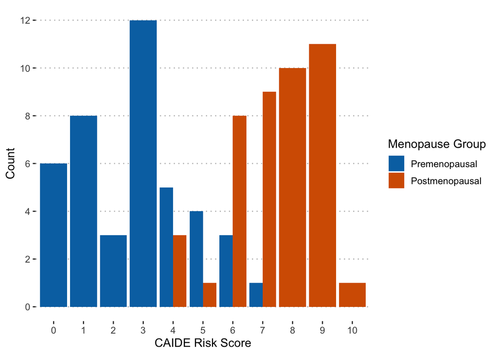

```r
cleaned_data_df$CAIDE <- as.factor(cleaned_data_df$CAIDE)

p_CAIDE_meno <- ggplot(cleaned_data_df, aes(x = CAIDE, fill = group_var)) +
  geom_bar(position = "dodge") +
  scale_fill_manual(values = c("#0072B2", "#D55E00"), name = "Menopause Group", labels = c("Premenopausal", "Postmenopausal")) +
  labs(x = "CAIDE Risk Score", y = "Count") +
  scale_y_continuous(breaks = seq(0, 12, 2), limits = c(0, 12)) +
  theme_pubclean() +
  theme(legend.position = "right")

p_CAIDE_meno
```

# 2 Part IV. Main Analyses

## 2.1 Analysis 1: Mixed-Effect Linear Regressions for Models Predicting Spatial Source Retrieval and Novelty Detection, Stratified by Menopause Group

### 2.1.1 Spatial Source Retrieval (Model 1.2a, Table 3)

#### 2.1.1.1 Premenopausal Group

```r
meno_cs_acc_pre <- cleaned_data_df %>%
  filter(group_var == "pre") %>%
  mutate(
    s2_age_std = scale(s2_age),
    edu_std = scale(edu)
  ) %>%
  select(id, s2_age, s2_age_std, edu, edu_std, cs_rate_easy, cs_rate_hard) %>%
  pivot_longer(cols = starts_with("cs_rate"), names_to = "task", values_to = "cs_rate") %>%
  mutate(
    id = factor(id),
    task = factor(str_replace(task, "cs_rate_", ""), levels = c("easy", "hard"))
  )

contrasts(meno_cs_acc_pre$task) <- contr.sum(2)
```

##### 2.1.1.1.1 Fit Linear Mixed Models

```r
lmm1 <- lmerTest::lmer(cs_rate ~ task + s2_age_std + edu_std + (1|id), data = meno_cs_acc_pre, REML = FALSE)
lmm2 <- lmerTest::lmer(cs_rate ~ task * s2_age_std + edu_std + (1|id), data = meno_cs_acc_pre, REML = FALSE)
anova(lmm1, lmm2)
```

|  | npar | AIC | BIC | logLik | deviance | Chisq | Df | Pr(>Chisq) |
| --- | --- | --- | --- | --- | --- | --- | --- | --- |
| lmm1 | 6 | -67.22481 | -52.63991 | 39.61240 | -79.22481 | NA | NA | NA |
| lmm2 | 7 | -65.33056 | -48.31484 | 39.66528 | -79.33056 | 0.1057499 | 1 | 0.7450356 |

```r
lmm_meno_cs_pre <- update(lmm1, REML = TRUE)
anova(lmm_meno_cs_pre, type = "III")
```

|  | Sum Sq | Mean Sq | NumDF | DenDF | F value | Pr(>F) |
| --- | --- | --- | --- | --- | --- | --- |
| task | 1.107644056 | 1.107644056 | 1 | 41 | 115.9378043 | 1.602510e-13 |
| s2_age_std | 0.020184495 | 0.020184495 | 1 | 39 | 2.1127239 | 1.540793e-01 |
| edu_std | 0.002236933 | 0.002236933 | 1 | 39 | 0.2341412 | 6.311761e-01 |

```r
summary(lmm_meno_cs_pre)$coefficients
```

```
##                Estimate Std. Error df    t value     Pr(>|t|)
## (Intercept)  0.52504960 0.02673115 39 19.6418668 7.935495e-22
## task1        0.11483135 0.01066468 41 10.7674419 1.602510e-13
## s2_age_std  -0.03933780 0.02706380 39 -1.4535212 1.540793e-01
## edu_std      0.01309567 0.02706380 39  0.4838814 6.311761e-01
```

```r
sjPlot::tab_model(lmm_meno_cs_pre, dv.labels = "Pre-Meno: Task, Age, Edu ~ CS", p.style = "scientific_stars", df.method = "satterthwaite")
```

Pre-Meno: Task, Age, Edu ~ CS

Predictors

Estimates

CI

p

(Intercept)

0.53 ***

0.47 – 0.58

**7.935e-22**

task1

0.11 ***

0.09 – 0.14

**1.603e-13**

s2 age std

-0.04

-0.09 – 0.02

1.541e-01

edu std

0.01

-0.04 – 0.07

6.312e-01

Random Effects

σ<sup>2</sup>

0.01

τ<sub>00</sub> <sub>id</sub>

0.03

ICC

0.73

N <sub>id</sub>

42

Observations

84

Marginal R<sup>2</sup> / Conditional R<sup>2</sup>

0.302 / 0.808

- p<0.05 ** p<0.01 *** p<0.001

```r
check_collinearity(lmm_meno_cs_pre)
```

| Term | VIF | VIF_CI_low | VIF_CI_high | SE_factor | Tolerance | Tolerance_CI_low | Tolerance_CI_high |
| --- | --- | --- | --- | --- | --- | --- | --- |
| task | 1.000000 | 1 | NaN | 1.000000 | 1.0000000 | NaN | 1 |
| s2_age_std | 1.000638 | 1 | Inf | 1.000319 | 0.9993627 | 0 | 1 |
| edu_std | 1.000638 | 1 | Inf | 1.000319 | 0.9993627 | 0 | 1 |

##### 2.1.1.1.2 Estimated Marginal Means

```r
library(plyr)
out_EM_means_lmm_meno_cs_pre <- emmeans(lmm_meno_cs_pre, pairwise ~ task) %>% as.data.frame()
detach("package:plyr", unload = TRUE)
```

##### 2.1.1.1.3 Visualizations

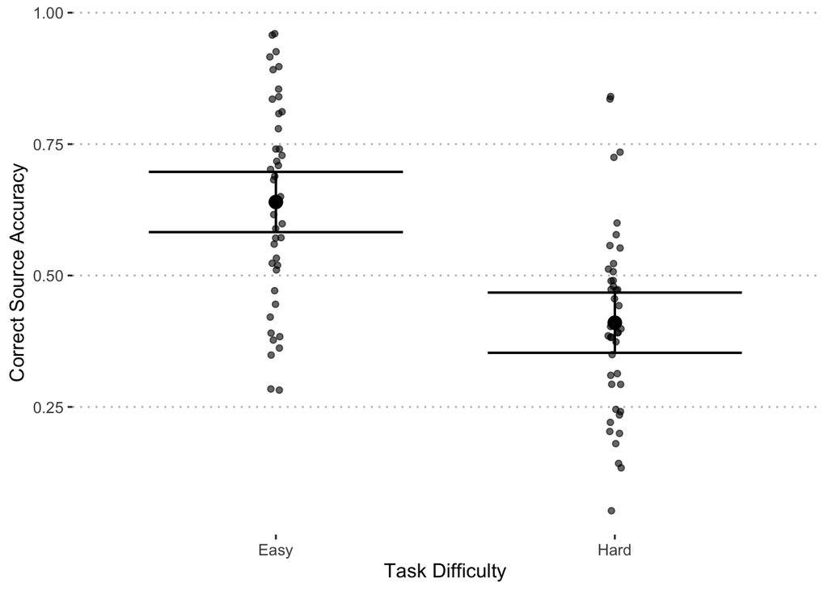

```r
library(jtools)
effect_plot(lmm_meno_cs_pre, pred = task, plot.points = TRUE, jitter = 0.02, line.thickness = 0.7) +
  scale_x_discrete(labels = c("Easy", "Hard")) +
  labs(x = "Task Difficulty", y = "Correct Source Accuracy") +
  theme_pubclean()
```

#### 2.1.1.2 Postmenopausal Group

```r
meno_cs_acc_post <- cleaned_data_df %>%
  filter(group_var == "post") %>%
  mutate(
    s2_age_std = scale(s2_age),
    edu_std = scale(edu)
  ) %>%
  select(id, s2_age, s2_age_std, edu, edu_std, cs_rate_easy, cs_rate_hard) %>%
  pivot_longer(cols = starts_with("cs_rate"), names_to = "task", values_to = "cs_rate") %>%
  mutate(
    id = factor(id),
    task = factor(str_replace(task, "cs_rate_", ""), levels = c("easy", "hard"))
  )

contrasts(meno_cs_acc_post$task) <- contr.sum(2)
```

##### 2.1.1.2.1 Fit Linear Mixed Models

```r
lmm1_post <- lmerTest::lmer(cs_rate ~ task + s2_age_std + edu_std + (1|id), data = meno_cs_acc_post, REML = FALSE)
lmm2_post <- lmerTest::lmer(cs_rate ~ task * s2_age_std + edu_std + (1|id), data = meno_cs_acc_post, REML = FALSE)
anova(lmm1_post, lmm2_post)
```

|  | npar | AIC | BIC | logLik | deviance | Chisq | Df | Pr(>Chisq) |
| --- | --- | --- | --- | --- | --- | --- | --- | --- |
| lmm1_post | 6 | -102.3785 | -87.6524 | 57.18924 | -114.3785 | NA | NA | NA |
| lmm2_post | 7 | -103.5875 | -86.4071 | 58.79377 | -117.5875 | 3.209051 | 1 | 0.07323197 |

```r
lmm_meno_cs_post <- update(lmm1_post, REML = TRUE)
anova(lmm_meno_cs_post, type = "III")
```

|  | Sum Sq | Mean Sq | NumDF | DenDF | F value | Pr(>F) |
| --- | --- | --- | --- | --- | --- | --- |
| task | 0.49865474 | 0.49865474 | 1 | 42 | 66.137413 | 3.657363e-10 |
| s2_age_std | 0.05368215 | 0.05368215 | 1 | 40 | 7.119953 | 1.095618e-02 |
| edu_std | 0.03341906 | 0.03341906 | 1 | 40 | 4.432426 | 4.158906e-02 |

```r
summary(lmm_meno_cs_post)$coefficients
```

```
##                Estimate  Std. Error df   t value     Pr(>|t|)
## (Intercept)  0.35731589 0.020174829 40 17.710975 1.555868e-20
## task1        0.07614664 0.009363261 42  8.132491 3.657363e-10
## s2_age_std  -0.05447542 0.020415594 40 -2.668324 1.095618e-02
## edu_std      0.04298162 0.020415594 40  2.105333 4.158906e-02
```

```r
sjPlot::tab_model(lmm_meno_cs_post, dv.labels = "Post-Meno: Task, Age, Edu ~ CS", p.style = "scientific_stars", df.method = "satterthwaite")
```

Post-Meno: Task, Age, Edu ~ CS

Predictors

Estimates

CI

p

(Intercept)

0.36 ***

0.32 – 0.40

**1.556e-20**

task1

0.08 ***

0.06 – 0.10

**3.657e-10**

s2 age std

-0.05 *

-0.10 – -0.01

**1.096e-02**

edu std

0.04 *

0.00 – 0.08

**4.159e-02**

Random Effects

σ<sup>2</sup>

0.01

τ<sub>00</sub> <sub>id</sub>

0.01

ICC

0.65

N <sub>id</sub>

43

Observations

86

Marginal R<sup>2</sup> / Conditional R<sup>2</sup>

0.334 / 0.764

- p<0.05 ** p<0.01 *** p<0.001

```r
check_collinearity(lmm_meno_cs_post)
```

| Term | VIF | VIF_CI_low | VIF_CI_high | SE_factor | Tolerance | Tolerance_CI_low | Tolerance_CI_high |
| --- | --- | --- | --- | --- | --- | --- | --- |
| task | 1.000000 | 1 | NaN | 1.000000 | 1.000000 | NaN | 1 |
| s2_age_std | 1.000196 | 1 | Inf | 1.000098 | 0.999804 | 0 | 1 |
| edu_std | 1.000196 | 1 | Inf | 1.000098 | 0.999804 | 0 | 1 |

##### 2.1.1.2.2 Visualizations

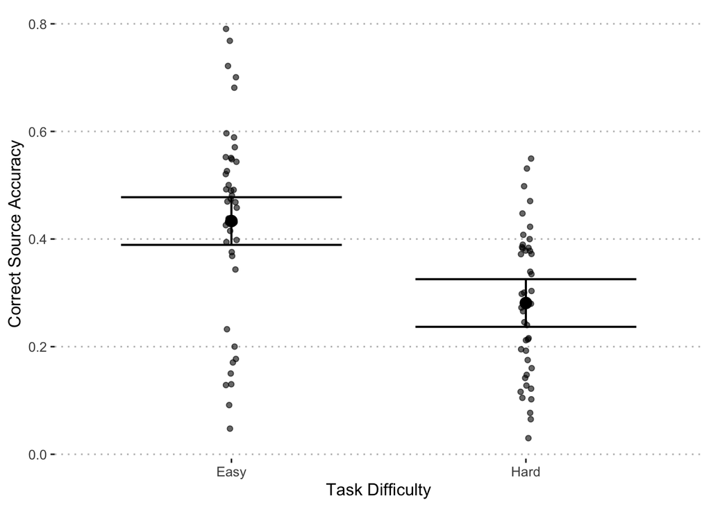

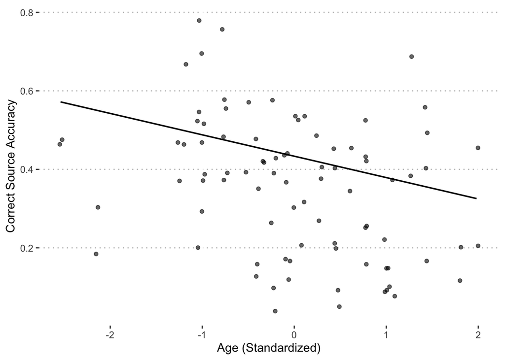

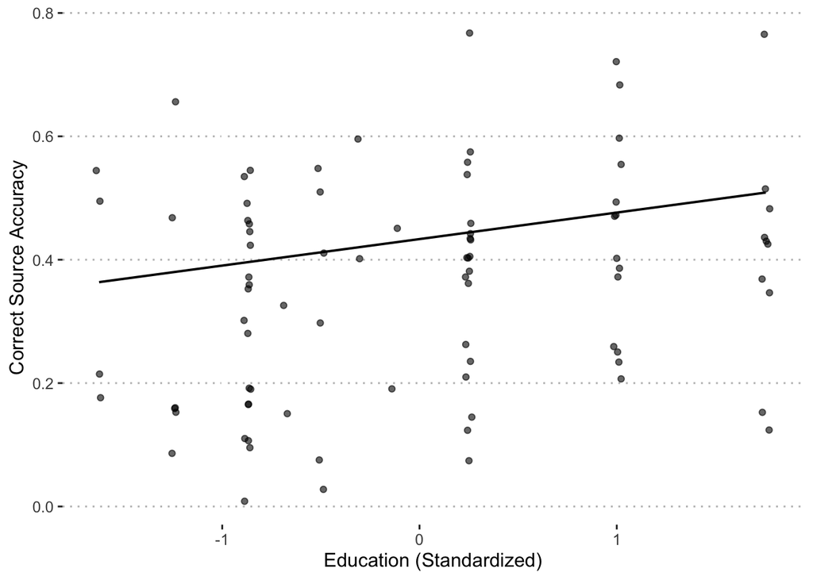

```r
# Task Effect
plot_task <- effect_plot(lmm_meno_cs_post, pred = task, plot.points = TRUE, jitter = 0.02, line.thickness = 0.7) +
  scale_x_discrete(labels = c("Easy", "Hard")) +
  labs(x = "Task Difficulty", y = "Correct Source Accuracy") +
  theme_pubclean()

# Age Effect
plot_age <- effect_plot(lmm_meno_cs_post, pred = s2_age_std, plot.points = TRUE, jitter = 0.02, line.thickness = 0.7) +
  labs(x = "Age (Standardized)", y = "Correct Source Accuracy") +
  theme_pubclean()

# Education Effect
plot_edu <- effect_plot(lmm_meno_cs_post, pred = edu_std, plot.points = TRUE, jitter = 0.02, line.thickness = 0.7) +
  labs(x = "Education (Standardized)", y = "Correct Source Accuracy") +
  theme_pubclean()

list(plot_task, plot_age, plot_edu)
```

### 2.1.2 Novelty Detection (Model 1.2b, Table 4 in manuscript)

#### 2.1.2.1 Premenopausal Group

```r
meno_cr_acc_pre <- cleaned_data_df %>%
  filter(group_var == "pre") %>%
  mutate(
    s2_age_std = scale(s2_age),
    edu_std = scale(edu)
  ) %>%
  select(id, s2_age, s2_age_std, edu, edu_std, cr_rate_easy, cr_rate_hard) %>%
  pivot_longer(cols = starts_with("cr_rate"), names_to = "task", values_to = "cr_rate") %>%
  mutate(
    id = factor(id),
    task = factor(str_replace(task, "cr_rate_", ""), levels = c("easy", "hard"))
  )

contrasts(meno_cr_acc_pre$task) <- contr.sum(2)
```

##### 2.1.2.1.1 Model Fitting

```r
lmm1_cr_pre <- lmerTest::lmer(cr_rate ~ task + s2_age_std + edu_std + (1|id), data = meno_cr_acc_pre, REML = FALSE)
lmm2_cr_pre <- lmerTest::lmer(cr_rate ~ task * s2_age_std + edu_std + (1|id), data = meno_cr_acc_pre, REML = FALSE)
anova(lmm1_cr_pre, lmm2_cr_pre)
```

|  | npar | AIC | BIC | logLik | deviance | Chisq | Df | Pr(>Chisq) |
| --- | --- | --- | --- | --- | --- | --- | --- | --- |
| lmm1_cr_pre | 6 | -144.5241 | -129.9392 | 78.26204 | -156.5241 | NA | NA | NA |
| lmm2_cr_pre | 7 | -142.5248 | -125.5090 | 78.26238 | -156.5248 | 0.0006733398 | 1 | 0.9792982 |

```r
lmm_meno_cr_pre <- update(lmm1_cr_pre, REML = TRUE)
anova(lmm_meno_cr_pre, type = "III")
```

|  | Sum Sq | Mean Sq | NumDF | DenDF | F value | Pr(>F) |
| --- | --- | --- | --- | --- | --- | --- |
| task | 0.0373315559 | 0.0373315559 | 1 | 41 | 16.9145786 | 0.0001833355 |
| s2_age_std | 0.0013991206 | 0.0013991206 | 1 | 39 | 0.6339284 | 0.4307380215 |
| edu_std | 0.0009129771 | 0.0009129771 | 1 | 39 | 0.4136614 | 0.5238808445 |

```r
summary(lmm_meno_cr_pre)$coefficients
```

```
##                Estimate  Std. Error df    t value     Pr(>|t|)
## (Intercept)  0.83804563 0.022158844 39 37.8199170 2.376942e-32
## task1        0.02108135 0.005125873 41  4.1127337 1.833355e-04
## s2_age_std  -0.01786234 0.022434595 39 -0.7961962 4.307380e-01
## edu_std      0.01442915 0.022434595 39  0.6431651 5.238808e-01
```

```r
sjPlot::tab_model(lmm_meno_cr_pre, dv.labels = "Pre-Meno: Task, Age, Edu ~ CR", p.style = "scientific_stars", df.method = "satterthwaite")
```

Pre-Meno: Task, Age, Edu ~ CR

Predictors

Estimates

CI

p

(Intercept)

0.84 ***

0.79 – 0.88

**2.377e-32**

task1

0.02 ***

0.01 – 0.03

**1.833e-04**

s2 age std

-0.02

-0.06 – 0.03

4.307e-01

edu std

0.01

-0.03 – 0.06

5.239e-01

Random Effects

σ<sup>2</sup>

0.00

τ<sub>00</sub> <sub>id</sub>

0.02

ICC

0.90

N <sub>id</sub>

42

Observations

84

Marginal R<sup>2</sup> / Conditional R<sup>2</sup>

0.043 / 0.903

- p<0.05 ** p<0.01 *** p<0.001

```r
check_collinearity(lmm_meno_cr_pre)
```

| Term | VIF | VIF_CI_low | VIF_CI_high | SE_factor | Tolerance | Tolerance_CI_low | Tolerance_CI_high |
| --- | --- | --- | --- | --- | --- | --- | --- |
| task | 1.000000 | 1 | NaN | 1.000000 | 1.0000000 | NaN | 1 |
| s2_age_std | 1.000638 | 1 | Inf | 1.000319 | 0.9993627 | 0 | 1 |
| edu_std | 1.000638 | 1 | Inf | 1.000319 | 0.9993627 | 0 | 1 |

##### 2.1.2.1.2 Visualization

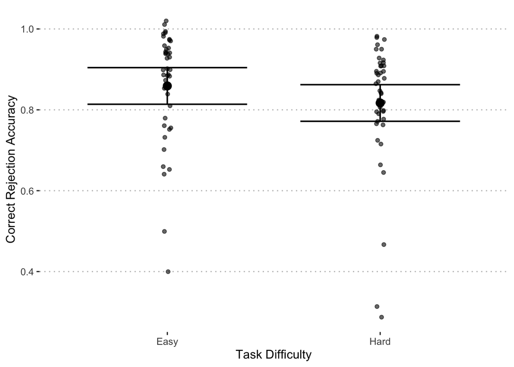

```r
effect_plot(model = lmm_meno_cr_pre, pred = task, plot.points = TRUE, jitter = 0.02, line.thickness = 0.7, x.label = "Task Difficulty", y.label = "Correct Rejection Accuracy") +
  scale_x_discrete(labels = c("Easy", "Hard")) +
  theme_pubclean()
```

#### 2.1.2.2 Postmenopausal Group

```r
meno_cr_acc_post <- cleaned_data_df %>%
  filter(group_var == "post") %>%
  mutate(
    s2_age_std = scale(s2_age),
    edu_std = scale(edu)
  ) %>%
  select(id, s2_age, s2_age_std, edu, edu_std, cr_rate_easy, cr_rate_hard) %>%
  pivot_longer(cols = starts_with("cr_rate"), names_to = "task", values_to = "cr_rate") %>%
  mutate(
    id = factor(id),
    task = factor(str_replace(task, "cr_rate_", ""), levels = c("easy", "hard"))
  )

contrasts(meno_cr_acc_post$task) <- contr.sum(2)
```

##### 2.1.2.2.1 Model Fitting

```r
lmm1_cr_post <- lmerTest::lmer(cr_rate ~ task + s2_age_std + edu_std + (1|id), data = meno_cr_acc_post, REML = FALSE)
lmm2_cr_post <- lmerTest::lmer(cr_rate ~ task * s2_age_std + edu_std + (1|id), data = meno_cr_acc_post, REML = FALSE)
anova(lmm1_cr_post, lmm2_cr_post)
```

|  | npar | AIC | BIC | logLik | deviance | Chisq | Df | Pr(>Chisq) |
| --- | --- | --- | --- | --- | --- | --- | --- | --- |
| lmm1_cr_post | 6 | -87.05188 | -72.32580 | 49.52594 | -99.05188 | NA | NA | NA |
| lmm2_cr_post | 7 | -85.71339 | -68.53296 | 49.85670 | -99.71339 | 0.6615113 | 1 | 0.4160269 |

```r
lmm_meno_cr_post <- update(lmm1_cr_post, REML = TRUE)
anova(lmm_meno_cr_post, type = "III")
```

|  | Sum Sq | Mean Sq | NumDF | DenDF | F value | Pr(>F) |
| --- | --- | --- | --- | --- | --- | --- |
| task | 0.0373263889 | 0.0373263889 | 1 | 42 | 6.8481148 | 0.01228116 |
| s2_age_std | 0.0006087768 | 0.0006087768 | 1 | 40 | 0.1116897 | 0.73997452 |
| edu_std | 0.0051567025 | 0.0051567025 | 1 | 40 | 0.9460784 | 0.33656502 |

```r
summary(lmm_meno_cr_post)$coefficients
```

```
##                Estimate  Std. Error df    t value     Pr(>|t|)
## (Intercept)  0.74773902 0.028357121 40 26.3686509 6.631176e-27
## task1        0.02083333 0.007961103 42  2.6168903 1.228116e-02
## s2_age_std  -0.00959005 0.028695532 40 -0.3342001 7.399745e-01
## edu_std     -0.02791116 0.028695532 40 -0.9726656 3.365650e-01
```

```r
sjPlot::tab_model(lmm_meno_cr_post, dv.labels = "Post-Meno: Task, Age, Edu ~ CR", p.style = "scientific_stars", df.method = "satterthwaite")
```

Post-Meno: Task, Age, Edu ~ CR

Predictors

Estimates

CI

p

(Intercept)

0.75 ***

0.69 – 0.81

**6.631e-27**

task1

0.02 *

0.00 – 0.04

**1.228e-02**

s2 age std

-0.01

-0.07 – 0.05

7.400e-01

edu std

-0.03

-0.09 – 0.03

3.366e-01

Random Effects

σ<sup>2</sup>

0.01

τ<sub>00</sub> <sub>id</sub>

0.03

ICC

0.85

N <sub>id</sub>

43

Observations

86

Marginal R<sup>2</sup> / Conditional R<sup>2</sup>

0.033 / 0.859

- p<0.05 ** p<0.01 *** p<0.001

```r
check_collinearity(lmm_meno_cr_post)
```

| Term | VIF | VIF_CI_low | VIF_CI_high | SE_factor | Tolerance | Tolerance_CI_low | Tolerance_CI_high |
| --- | --- | --- | --- | --- | --- | --- | --- |
| task | 1.000000 | 1 | NaN | 1.000000 | 1.000000 | NaN | 1 |
| s2_age_std | 1.000196 | 1 | Inf | 1.000098 | 0.999804 | 0 | 1 |
| edu_std | 1.000196 | 1 | Inf | 1.000098 | 0.999804 | 0 | 1 |

##### 2.1.2.2.2 Visualization

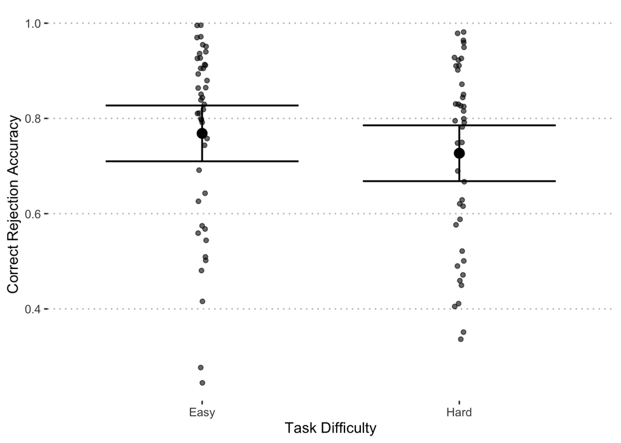

```r
effect_plot(model = lmm_meno_cr_post, pred = task, plot.points = TRUE, jitter = 0.02, line.thickness = 0.7, x.label = "Task Difficulty", y.label = "Correct Rejection Accuracy") +
  scale_x_discrete(labels = c("Easy", "Hard")) +
  theme_pubclean()
```

## 2.2 Analyis 2: CAIDE Score between menopause groups

### 2.2.1 Conduct Mann-Whitney U test to examine differences in CAIDE score by menopause status.

```r
wilcox.test(as.numeric(CAIDE) ~ group_var, data = cleaned_data_df, exact=FALSE)
```

```
##
##  Wilcoxon rank sum test with continuity correction
##
## data:  as.numeric(CAIDE) by group_var
## W = 62, p-value = 1.049e-13
## alternative hypothesis: true location shift is not equal to 0
```

## 2.3 Analysis 3: CAIDE Score Predicting Spatial Source Retrieval and Novelty Detection, Stratified by Menopause

### 2.3.1 Spatial Source Memory (CS) ~ CAIDE in Premenopausal Females (Model 2.1a, Table 5)

Prepare data:

```r
cs_acc_CAIDE_pre <- cleaned_data_df %>%
  filter(group_var == "pre") %>%
  select(id, group_var, CAIDE, cs_rate_easy, cs_rate_hard) %>%
  mutate(CAIDE = factor(CAIDE)) %>%
  pivot_longer(cols = starts_with("cs_rate"), names_to = "task", values_to = "cs_rate") %>%
  mutate(task = str_replace(task, "cs_rate_", "")) %>%
  mutate(task = factor(task, levels = c("easy", "hard")))
```

Reverse Helmert contrast coding:

```r
cs_acc_CAIDE_pre <- cs_acc_CAIDE_pre %>%
  mutate(CAIDE = factor(CAIDE, levels = c("0","1","2","3","4","5","6","7")))

  # create contrasts
    r_helmert_1 = matrix(c(-1/2, 1/2, 0, 0, 0, 0, 0,0,
                            -1/3, -1/3, 2/3, 0, 0, 0, 0,0,
                            -1/4, -1/4, -1/4, 3/4, 0, 0, 0,0,
                            -1/5, -1/5, -1/5, -1/5, 4/5, 0, 0,0,
                            -1/6, -1/6, -1/6, -1/6, -1/6, 5/6, 0,0,
                            -1/7, -1/7, -1/7, -1/7, -1/7, -1/7, 6/7,0,
                           -1/8, -1/8, -1/8, -1/8, -1/8, -1/8, -1/8, 7/8
                            ), ncol = 7)

    r_helmert_1
```

```
##      [,1]       [,2]  [,3] [,4]       [,5]       [,6]   [,7]
## [1,] -0.5 -0.3333333 -0.25 -0.2 -0.1666667 -0.1428571 -0.125
## [2,]  0.5 -0.3333333 -0.25 -0.2 -0.1666667 -0.1428571 -0.125
## [3,]  0.0  0.6666667 -0.25 -0.2 -0.1666667 -0.1428571 -0.125
## [4,]  0.0  0.0000000  0.75 -0.2 -0.1666667 -0.1428571 -0.125
## [5,]  0.0  0.0000000  0.00  0.8 -0.1666667 -0.1428571 -0.125
## [6,]  0.0  0.0000000  0.00  0.0  0.8333333 -0.1428571 -0.125
## [7,]  0.0  0.0000000  0.00  0.0  0.0000000  0.8571429 -0.125
## [8,]  0.0  0.0000000  0.00  0.0  0.0000000  0.0000000  0.875
```

```r
contrasts(cs_acc_CAIDE_pre$task) <- contr.sum(2)
contrasts(cs_acc_CAIDE_pre$task)
```

```
##      [,1]
## easy    1
## hard   -1
```

```r
contrasts(cs_acc_CAIDE_pre$CAIDE) <- r_helmert_1
contrasts(cs_acc_CAIDE_pre$CAIDE)
```

```
##   [,1]       [,2]  [,3] [,4]       [,5]       [,6]   [,7]
## 0 -0.5 -0.3333333 -0.25 -0.2 -0.1666667 -0.1428571 -0.125
## 1  0.5 -0.3333333 -0.25 -0.2 -0.1666667 -0.1428571 -0.125
## 2  0.0  0.6666667 -0.25 -0.2 -0.1666667 -0.1428571 -0.125
## 3  0.0  0.0000000  0.75 -0.2 -0.1666667 -0.1428571 -0.125
## 4  0.0  0.0000000  0.00  0.8 -0.1666667 -0.1428571 -0.125
## 5  0.0  0.0000000  0.00  0.0  0.8333333 -0.1428571 -0.125
## 6  0.0  0.0000000  0.00  0.0  0.0000000  0.8571429 -0.125
## 7  0.0  0.0000000  0.00  0.0  0.0000000  0.0000000  0.875
```

Fit model:

```r
lmm_CAIDE_cs_pre <- lmerTest::lmer(cs_rate ~ task + CAIDE + (1|id), data = cs_acc_CAIDE_pre, REML = TRUE)
```

Outputs:

```r
anova(lmm_CAIDE_cs_pre, type = "III")
```

|  | Sum Sq | Mean Sq | NumDF | DenDF | F value | Pr(>F) |
| --- | --- | --- | --- | --- | --- | --- |
| task | 1.10764406 | 1.107644056 | 1 | 41 | 115.9378043 | 1.60251e-13 |
| CAIDE | 0.05594801 | 0.007992573 | 7 | 34 | 0.8365877 | 5.64832e-01 |

```r
summary(lmm_CAIDE_cs_pre)$coefficients
```

```
##                Estimate Std. Error df    t value     Pr(>|t|)
## (Intercept)  0.51005859 0.03483096 34 14.6438295 3.015754e-16
## task1        0.11483135 0.01066468 41 10.7674419 1.602510e-13
## CAIDE1       0.04383681 0.09533532 34  0.4598171 6.485745e-01
## CAIDE2      -0.11914062 0.11251414 34 -1.0588947 2.971129e-01
## CAIDE3       0.01345486 0.06899864 34  0.1950018 8.465521e-01
## CAIDE4      -0.16334635 0.08724614 34 -1.8722473 6.979420e-02
## CAIDE5       0.04015625 0.09445966 34  0.4251153 6.734312e-01
## CAIDE6       0.03346354 0.10672339 34  0.3135540 7.557755e-01
## CAIDE7      -0.02340030 0.17919349 34 -0.1305868 8.968718e-01
```

```r
sjPlot::tab_model(
  lmm_CAIDE_cs_pre,
  dv.labels = "Pre-Meno: Task and CAIDE Risk score predicting CS",
  p.style = "scientific_stars",
  df.method = "satterthwaite"
)
```

Pre-Meno: Task and CAIDE Risk score predicting CS

Predictors

Estimates

CI

p

(Intercept)

0.51 ***

0.44 – 0.58

**3.016e-16**

task1

0.11 ***

0.09 – 0.14

**1.603e-13**

CAIDE [1]

0.04

-0.15 – 0.24

6.486e-01

CAIDE [2]

-0.12

-0.35 – 0.11

2.971e-01

CAIDE [3]

0.01

-0.13 – 0.15

8.466e-01

CAIDE [4]

-0.16

-0.34 – 0.01

6.979e-02

CAIDE [5]

0.04

-0.15 – 0.23

6.734e-01

CAIDE [6]

0.03

-0.18 – 0.25

7.558e-01

CAIDE [7]

-0.02

-0.39 – 0.34

8.969e-01

Random Effects

σ<sup>2</sup>

0.01

τ<sub>00</sub> <sub>id</sub>

0.03

ICC

0.73

N <sub>id</sub>

42

Observations

84

Marginal R<sup>2</sup> / Conditional R<sup>2</sup>

0.331 / 0.822

- p<0.05 ** p<0.01 *** p<0.001

```r
check_collinearity(lmm_CAIDE_cs_pre)
```

| Term | VIF | VIF_CI_low | VIF_CI_high | SE_factor | Tolerance | Tolerance_CI_low | Tolerance_CI_high |
| --- | --- | --- | --- | --- | --- | --- | --- |
| task | 1 | 1 | NaN | 1 | 1 | NaN | 1 |
| CAIDE | 1 | 1 | NaN | 1 | 1 | NaN | 1 |

```r
check_outliers(lmm_CAIDE_cs_pre)
```

```
## OK: No outliers detected.
## - Based on the following method and threshold: cook (0.7).
## - For variable: (Whole model)
```

Visualizations:

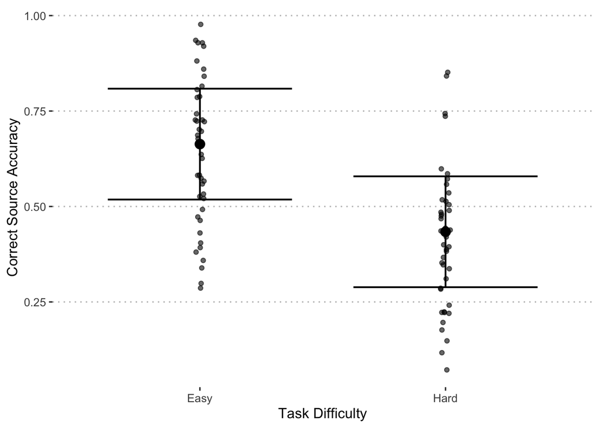

```r
effect_plot(model = lmm_CAIDE_cs_pre, pred = task, plot.points = TRUE, jitter = 0.02, line.thickness = 0.7) +
  scale_x_discrete(labels = c("Easy", "Hard")) +
  labs(x = "Task Difficulty", y = "Correct Source Accuracy") +
  theme_pubclean()
```

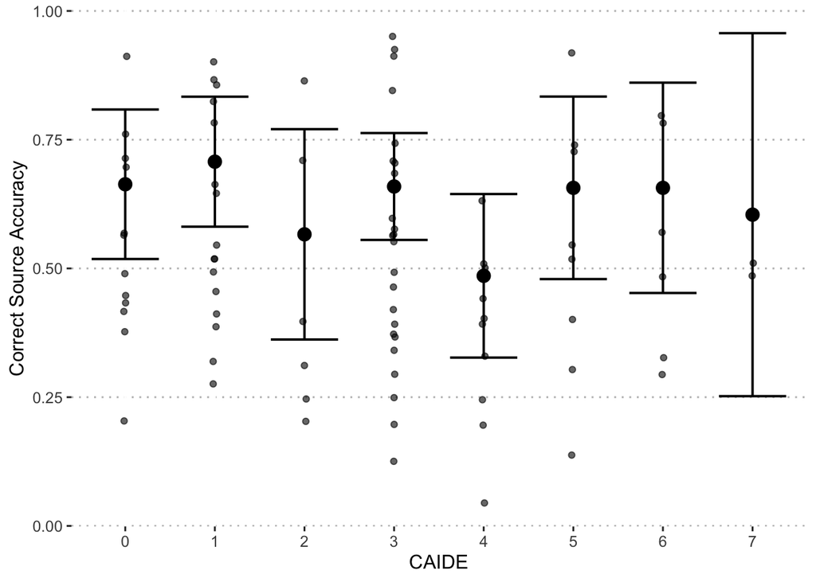

```r
effect_plot(model = lmm_CAIDE_cs_pre, pred = CAIDE, plot.points = TRUE, jitter = 0.02, line.thickness = 0.7) +
  labs(x = "CAIDE", y = "Correct Source Accuracy") +
  theme_pubclean()
```

### 2.3.2 Spatial Source Memory (CS) ~ CAIDE in Postmenopausal Females (Model 2.1b, Table 6)

Prepare data:

```r
cs_acc_CAIDE_post <- cleaned_data_df %>%
  filter(group_var == "post") %>%
  select(id, group_var, CAIDE, cs_rate_easy, cs_rate_hard) %>%
  mutate(CAIDE = factor(CAIDE)) %>%
  pivot_longer(cols = starts_with("cs_rate"), names_to = "task", values_to = "cs_rate") %>%
  mutate(task = str_replace(task, "cs_rate_", "")) %>%
  mutate(task = factor(task, levels = c("easy", "hard")))
```

Reverse Helmert contrast coding:

```r
cs_acc_CAIDE_post <- mutate(cs_acc_CAIDE_post, CAIDE = factor(CAIDE, levels = c("4", "5", "6", "7", "8", "9", "10")))

r_helmert_1 = matrix(c(-1/2, 1/2, 0, 0, 0, 0, 0,
                            -1/3, -1/3, 2/3, 0, 0, 0, 0,
                            -1/4, -1/4, -1/4, 3/4, 0, 0, 0,
                            -1/5, -1/5, -1/5, -1/5, 4/5, 0, 0,
                            -1/6, -1/6, -1/6, -1/6, -1/6, 5/6, 0,
                            -1/7, -1/7, -1/7, -1/7, -1/7, -1/7, 6/7
                            ), ncol = 6)

    r_helmert_1
```

```
##      [,1]       [,2]  [,3] [,4]       [,5]       [,6]
## [1,] -0.5 -0.3333333 -0.25 -0.2 -0.1666667 -0.1428571
## [2,]  0.5 -0.3333333 -0.25 -0.2 -0.1666667 -0.1428571
## [3,]  0.0  0.6666667 -0.25 -0.2 -0.1666667 -0.1428571
## [4,]  0.0  0.0000000  0.75 -0.2 -0.1666667 -0.1428571
## [5,]  0.0  0.0000000  0.00  0.8 -0.1666667 -0.1428571
## [6,]  0.0  0.0000000  0.00  0.0  0.8333333 -0.1428571
## [7,]  0.0  0.0000000  0.00  0.0  0.0000000  0.8571429
```

```r
contrasts(cs_acc_CAIDE_post$task) <- contr.sum(2)
contrasts(cs_acc_CAIDE_post$CAIDE) <- r_helmert_1
```

Fit model:

```r
lmm_CAIDE_cs_post <- lmerTest::lmer(cs_rate ~ task + CAIDE + (1|id), data = cs_acc_CAIDE_post, REML = TRUE)
```

Outputs:

```r
anova(lmm_CAIDE_cs_post, type = "III")
```

|  | Sum Sq | Mean Sq | NumDF | DenDF | F value | Pr(>F) |
| --- | --- | --- | --- | --- | --- | --- |
| task | 0.4986547 | 0.49865474 | 1 | 42 | 66.137413 | 3.657363e-10 |
| CAIDE | 0.1274743 | 0.02124571 | 6 | 36 | 2.817854 | 2.367382e-02 |

```r
summary(lmm_CAIDE_cs_post)$coefficients
```

```
##                Estimate  Std. Error df    t value     Pr(>|t|)
## (Intercept)  0.41782808 0.031043228 36 13.4595564 1.286201e-15
## task1        0.07614664 0.009363261 42  8.1324912 3.657363e-10
## CAIDE1       0.21875000 0.151026074 36  1.4484254 1.561526e-01
## CAIDE2      -0.05208333 0.088546885 36 -0.5882006 5.600699e-01
## CAIDE3      -0.07542438 0.068356796 36 -1.1033926 2.771780e-01
## CAIDE4       0.02996721 0.058212218 36  0.5147924 6.098445e-01
## CAIDE5      -0.14386083 0.051937415 36 -2.7698882 8.811481e-03
## CAIDE6       0.27815890 0.133952043 36  2.0765559 4.504031e-02
```

```r
sjPlot::tab_model(
  lmm_CAIDE_cs_post,
  dv.labels = "Post-Meno: Task and CAIDE Risk score predicting CS",
  p.style = "scientific_stars",
  df.method = "satterthwaite"
)
```

Post-Meno: Task and CAIDE Risk score predicting CS

Predictors

Estimates

CI

p

(Intercept)

0.42 ***

0.35 – 0.48

**1.286e-15**

task1

0.08 ***

0.06 – 0.10

**3.657e-10**

CAIDE1

0.22

-0.09 – 0.53

1.562e-01

CAIDE2

-0.05

-0.23 – 0.13

5.601e-01

CAIDE3

-0.08

-0.21 – 0.06

2.772e-01

CAIDE [4]

0.03

-0.09 – 0.15

6.098e-01

CAIDE [5]

-0.14 **

-0.25 – -0.04

**8.811e-03**

CAIDE [6]

0.28 *

0.01 – 0.55

**4.504e-02**

Random Effects

σ<sup>2</sup>

0.01

τ<sub>00</sub> <sub>id</sub>

0.01

ICC

0.64

N <sub>id</sub>

43

Observations

86

Marginal R<sup>2</sup> / Conditional R<sup>2</sup>

0.378 / 0.775

- p<0.05 ** p<0.01 *** p<0.001

```r
check_collinearity(lmm_CAIDE_cs_post)
```

| Term | VIF | VIF_CI_low | VIF_CI_high | SE_factor | Tolerance | Tolerance_CI_low | Tolerance_CI_high |
| --- | --- | --- | --- | --- | --- | --- | --- |
| task | 1 | 1 | NaN | 1 | 1 | NaN | 1 |
| CAIDE | 1 | 1 | NaN | 1 | 1 | NaN | 1 |

```r
check_outliers(lmm_CAIDE_cs_post)
```

```
## OK: No outliers detected.
## - Based on the following method and threshold: cook (0.7).
## - For variable: (Whole model)
```

Visualizations:

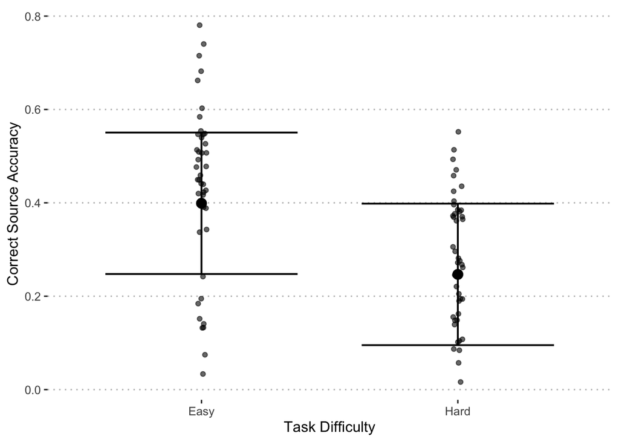

```r
effect_plot(model = lmm_CAIDE_cs_post, pred = task, plot.points = TRUE, jitter = 0.02, line.thickness = 0.7) +
  scale_x_discrete(labels = c("Easy", "Hard")) +
  labs(x = "Task Difficulty", y = "Correct Source Accuracy") +
  theme_pubclean()
```

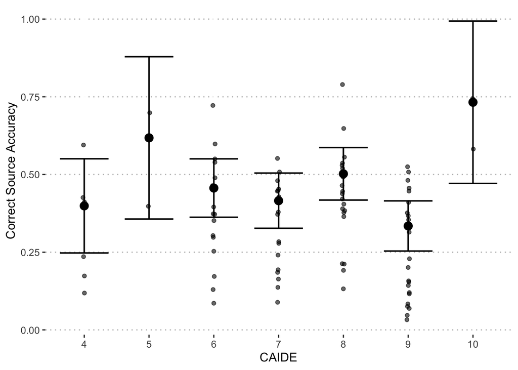

```r
effect_plot(model = lmm_CAIDE_cs_post, pred = CAIDE, plot.points = TRUE, jitter = 0.02, line.thickness = 0.7) +
  labs(x = "CAIDE", y = "Correct Source Accuracy") +
  theme_pubclean()
```

### 2.3.3 Novelty Detection (CR) ~ CAIDE in Premenopausal Females ( Model 2.2a, Table 5)

Prepare data:

```r
cr_acc_CAIDE_pre <- cleaned_data_df %>%
  filter(group_var == "pre") %>%
  select(id, group_var, CAIDE, cr_rate_easy, cr_rate_hard) %>%
  mutate(CAIDE = factor(CAIDE)) %>%
  pivot_longer(cols = starts_with("cr_rate"), names_to = "task", values_to = "cr_rate") %>%
  mutate(task = str_replace(task, "cr_rate_", "")) %>%
  mutate(task = factor(task, levels = c("easy", "hard")))
```

Reverse Helmert contrast coding:

```r
cr_acc_CAIDE_pre <- mutate(cr_acc_CAIDE_pre, CAIDE = factor(CAIDE, levels = c("0","1","2","3","4","5","6","7")))

  # create contrasts
    r_helmert_2 = matrix(c(-1/2, 1/2, 0, 0, 0, 0, 0,0,
                            -1/3, -1/3, 2/3, 0, 0, 0, 0,0,
                            -1/4, -1/4, -1/4, 3/4, 0, 0, 0,0,
                            -1/5, -1/5, -1/5, -1/5, 4/5, 0, 0,0,
                            -1/6, -1/6, -1/6, -1/6, -1/6, 5/6, 0,0,
                            -1/7, -1/7, -1/7, -1/7, -1/7, -1/7, 6/7,0,
                           -1/8, -1/8, -1/8, -1/8, -1/8, -1/8, -1/8, 7/8
                            ), ncol = 7)

    r_helmert_2
```

```
##      [,1]       [,2]  [,3] [,4]       [,5]       [,6]   [,7]
## [1,] -0.5 -0.3333333 -0.25 -0.2 -0.1666667 -0.1428571 -0.125
## [2,]  0.5 -0.3333333 -0.25 -0.2 -0.1666667 -0.1428571 -0.125
## [3,]  0.0  0.6666667 -0.25 -0.2 -0.1666667 -0.1428571 -0.125
## [4,]  0.0  0.0000000  0.75 -0.2 -0.1666667 -0.1428571 -0.125
## [5,]  0.0  0.0000000  0.00  0.8 -0.1666667 -0.1428571 -0.125
## [6,]  0.0  0.0000000  0.00  0.0  0.8333333 -0.1428571 -0.125
## [7,]  0.0  0.0000000  0.00  0.0  0.0000000  0.8571429 -0.125
## [8,]  0.0  0.0000000  0.00  0.0  0.0000000  0.0000000  0.875
```

```r
contrasts(cr_acc_CAIDE_pre$task) <- contr.sum(2)
contrasts(cr_acc_CAIDE_pre$CAIDE) <- r_helmert_2
```

Fit model:

```r
lmm_CAIDE_cr_pre <- lmerTest::lmer(cr_rate ~ task + CAIDE + (1|id), data = cr_acc_CAIDE_pre, REML = TRUE)
```

Outputs:

```r
anova(lmm_CAIDE_cr_pre, type = "III")
```

|  | Sum Sq | Mean Sq | NumDF | DenDF | F value | Pr(>F) |
| --- | --- | --- | --- | --- | --- | --- |
| task | 0.03733156 | 0.03733156 | 1 | 41 | 16.9145781 | 0.0001833355 |
| CAIDE | 0.01286663 | 0.00183809 | 7 | 34 | 0.8328213 | 0.5676911843 |

```r
summary(lmm_CAIDE_cr_pre)$coefficients
```

```
##                Estimate  Std. Error df    t value     Pr(>|t|)
## (Intercept)  0.83237847 0.028422022 34 29.2863914 1.053067e-25
## task1        0.02108135 0.005125873 41  4.1127336 1.833355e-04
## CAIDE1      -0.11197917 0.077793515 34 -1.4394409 1.591697e-01
## CAIDE2      -0.03255208 0.091811415 34 -0.3545538 7.251136e-01
## CAIDE3       0.01996528 0.056302812 34  0.3546053 7.250754e-01
## CAIDE4      -0.11419271 0.071192755 34 -1.6039934 1.179659e-01
## CAIDE5      -0.04812500 0.077078978 34 -0.6243596 5.365589e-01
## CAIDE6      -0.02013889 0.087086169 34 -0.2312524 8.185047e-01
## CAIDE7       0.04871032 0.146221692 34  0.3331265 7.410844e-01
```

```r
sjPlot::tab_model(
  lmm_CAIDE_cr_pre,
  dv.labels = "Pre-Meno: Task and CAIDE Risk score predicting CR",
  p.style = "scientific_stars",
  df.method = "satterthwaite"
)
```

Pre-Meno: Task and CAIDE Risk score predicting CR

Predictors

Estimates

CI

p

(Intercept)

0.83 ***

0.77 – 0.89

**1.053e-25**

task1

0.02 ***

0.01 – 0.03

**1.833e-04**

CAIDE [1]

-0.11

-0.27 – 0.05

1.592e-01

CAIDE [2]

-0.03

-0.22 – 0.15

7.251e-01

CAIDE [3]

0.02

-0.09 – 0.13

7.251e-01

CAIDE [4]

-0.11

-0.26 – 0.03

1.180e-01

CAIDE [5]

-0.05

-0.20 – 0.11

5.366e-01

CAIDE [6]

-0.02

-0.20 – 0.16

8.185e-01

CAIDE [7]

0.05

-0.25 – 0.35

7.411e-01

Random Effects

σ<sup>2</sup>

0.00

τ<sub>00</sub> <sub>id</sub>

0.02

ICC

0.90

N <sub>id</sub>

42

Observations

84

Marginal R<sup>2</sup> / Conditional R<sup>2</sup>

0.133 / 0.912

- p<0.05 ** p<0.01 *** p<0.001

Visualizations:

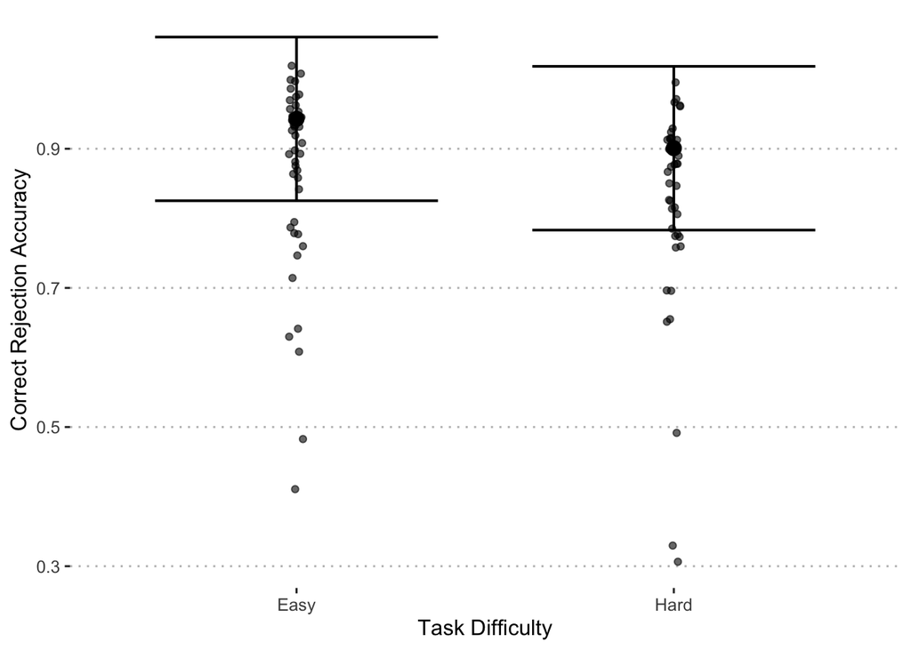

```r
effect_plot(model = lmm_CAIDE_cr_pre, pred = task, plot.points = TRUE, jitter = 0.02, line.thickness = 0.7) +
  scale_x_discrete(labels = c("Easy", "Hard")) +
  labs(x = "Task Difficulty", y = "Correct Rejection Accuracy") +
  theme_pubclean()
```

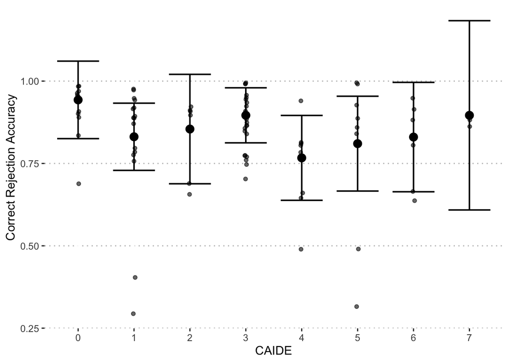

```r
effect_plot(model = lmm_CAIDE_cr_pre, pred = CAIDE, plot.points = TRUE, jitter = 0.02, line.thickness = 0.7) +
  labs(x = "CAIDE", y = "Correct Rejection Accuracy") +
  theme_pubclean()
```

### 2.3.4 Novelty Detection (CR) ~ CAIDE in Posmenopausal Females (Model 2.2b, Table 6)

Prepare data:

```r
cr_acc_CAIDE_post <- cleaned_data_df %>%
  filter(group_var == "post") %>%
  select(id, group_var, CAIDE, cr_rate_easy, cr_rate_hard) %>%
  mutate(CAIDE = factor(CAIDE)) %>%
  pivot_longer(cols = starts_with("cr_rate"), names_to = "task", values_to = "cr_rate") %>%
  mutate(task = str_replace(task, "cr_rate_", "")) %>%
  mutate(task = factor(task, levels = c("easy", "hard")))
```

Reverse Helmert contrast coding:

```r
cr_acc_CAIDE_post <- mutate(cr_acc_CAIDE_post, CAIDE = factor(CAIDE, levels = c("4", "5", "6", "7", "8", "9", "10")))

# create contrasts
    r_helmert_2 = matrix(c(-1/2, 1/2, 0, 0, 0, 0, 0,
                            -1/3, -1/3, 2/3, 0, 0, 0, 0,
                            -1/4, -1/4, -1/4, 3/4, 0, 0, 0,
                            -1/5, -1/5, -1/5, -1/5, 4/5, 0, 0,
                            -1/6, -1/6, -1/6, -1/6, -1/6, 5/6, 0,
                            -1/7, -1/7, -1/7, -1/7, -1/7, -1/7, 6/7
                            ), ncol = 6)

    r_helmert_2
```

```
##      [,1]       [,2]  [,3] [,4]       [,5]       [,6]
## [1,] -0.5 -0.3333333 -0.25 -0.2 -0.1666667 -0.1428571
## [2,]  0.5 -0.3333333 -0.25 -0.2 -0.1666667 -0.1428571
## [3,]  0.0  0.6666667 -0.25 -0.2 -0.1666667 -0.1428571
## [4,]  0.0  0.0000000  0.75 -0.2 -0.1666667 -0.1428571
## [5,]  0.0  0.0000000  0.00  0.8 -0.1666667 -0.1428571
## [6,]  0.0  0.0000000  0.00  0.0  0.8333333 -0.1428571
## [7,]  0.0  0.0000000  0.00  0.0  0.0000000  0.8571429
```

```r
contrasts(cr_acc_CAIDE_post$task) <- contr.sum(2)
contrasts(cr_acc_CAIDE_post$CAIDE) <- r_helmert_2
```

Fit model:

```r
lmm_CAIDE_cr_post <- lmerTest::lmer(cr_rate ~ task + CAIDE + (1|id), data = cr_acc_CAIDE_post, REML = TRUE)
```

Outputs:

```r
anova(lmm_CAIDE_cr_post, type = "III")
```

|  | Sum Sq | Mean Sq | NumDF | DenDF | F value | Pr(>F) |
| --- | --- | --- | --- | --- | --- | --- |
| task | 0.03732639 | 0.03732639 | 1 | 42 | 6.848115 | 0.01228116 |
| CAIDE | 0.03866730 | 0.00644455 | 6 | 36 | 1.182354 | 0.33750088 |

```r
summary(lmm_CAIDE_cr_post)$coefficients
```

```
##                Estimate  Std. Error df    t value     Pr(>|t|)
## (Intercept)  0.68872417 0.043074698 36 15.9890655 6.218845e-18
## task1        0.02083333 0.007961103 42  2.6168903 1.228116e-02
## CAIDE1      -0.40625000 0.209559473 36 -1.9385905 6.042249e-02
## CAIDE2       0.03255208 0.122865132 36  0.2649416 7.925656e-01
## CAIDE3       0.07460455 0.094849940 36  0.7865535 4.366906e-01
## CAIDE4       0.02883150 0.080773613 36  0.3569421 7.232190e-01
## CAIDE5       0.05737707 0.072066876 36  0.7961642 4.311556e-01
## CAIDE6      -0.26878931 0.185868034 36 -1.4461298 1.567915e-01
```

```r
sjPlot::tab_model(
  lmm_CAIDE_cr_post,
  dv.labels = "Post-Meno: Task and CAIDE Risk score predicting CR",
  p.style = "scientific_stars",
  df.method = "satterthwaite"
)
```

Post-Meno: Task and CAIDE Risk score predicting CR

Predictors

Estimates

CI

p

(Intercept)

0.69 ***

0.60 – 0.78

**6.219e-18**

task1

0.02 *

0.00 – 0.04

**1.228e-02**

CAIDE1

-0.41

-0.83 – 0.02

6.042e-02

CAIDE2

0.03

-0.22 – 0.28

7.926e-01

CAIDE3

0.07

-0.12 – 0.27

4.367e-01

CAIDE [4]

0.03

-0.13 – 0.19

7.232e-01

CAIDE [5]

0.06

-0.09 – 0.20

4.312e-01

CAIDE [6]

-0.27

-0.65 – 0.11

1.568e-01

Random Effects

σ<sup>2</sup>

0.01

τ<sub>00</sub> <sub>id</sub>

0.03

ICC

0.85

N <sub>id</sub>

43

Observations

86

Marginal R<sup>2</sup> / Conditional R<sup>2</sup>

0.143 / 0.869

- p<0.05 ** p<0.01 *** p<0.001

Visualizations:

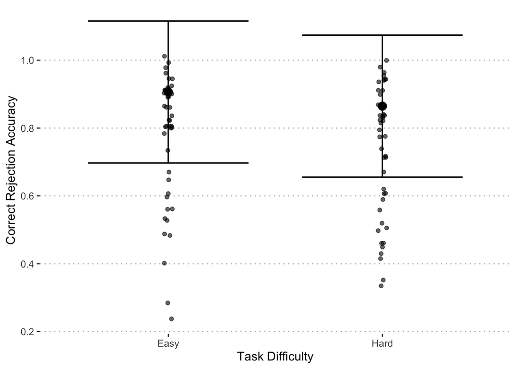

```r
effect_plot(model = lmm_CAIDE_cr_post, pred = task, plot.points = TRUE, jitter = 0.02, line.thickness = 0.7) +
  scale_x_discrete(labels = c("Easy", "Hard")) +
  labs(x = "Task Difficulty", y = "Correct Rejection Accuracy") +
  theme_pubclean()
```

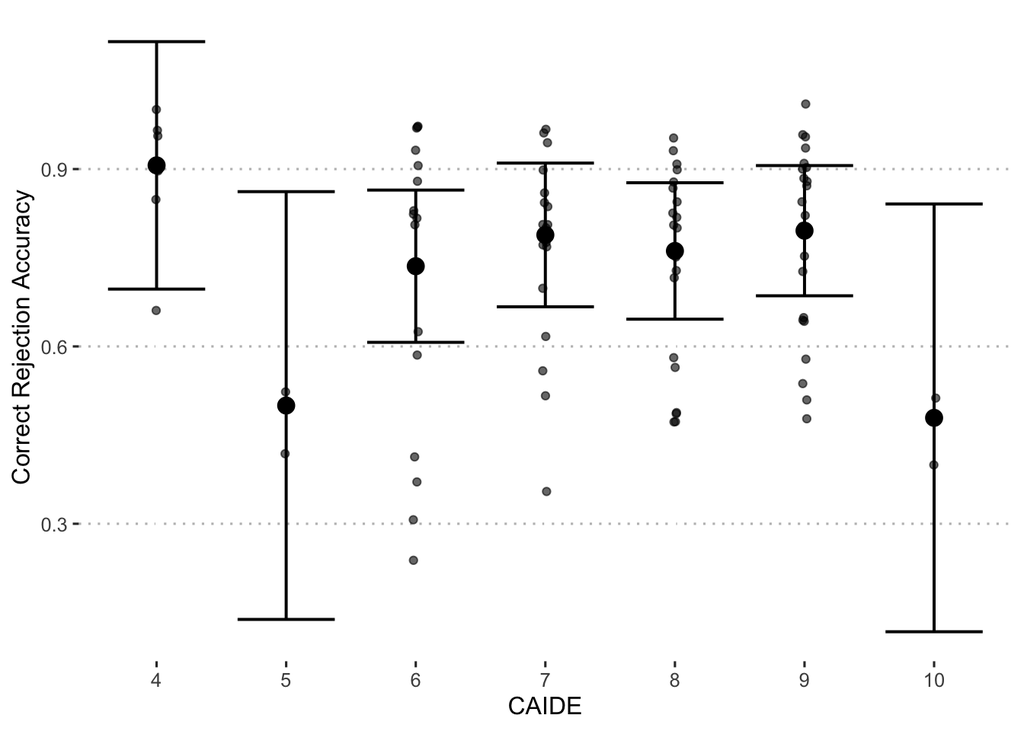

```r
effect_plot(model = lmm_CAIDE_cr_post, pred = CAIDE, plot.points = TRUE, jitter = 0.02, line.thickness = 0.7) +
  labs(x = "CAIDE", y = "Correct Rejection Accuracy") +
  theme_pubclean()
```

# 3 Part V: Post-Hocs on individual CAIDE risk score variables (Table 1)

## 3.1 Risk Bin Distirbution for each CAIDE Variable

Prepare long format dataframe:

```r
x_vars <- c("Age_coded", "BMI_coded", "Systolic_coded", "Exercise_coded", "Chol_coded", "Edu_coded")

risk_factors_df_long_2 <- cleaned_data_df %>%
  select(id, group_var, all_of(x_vars)) %>%
  mutate(across(all_of(x_vars), as.factor)) %>%
  pivot_longer(cols = all_of(x_vars), names_to = "risk_factor", values_to = "value") %>%
  convert_as_factor(id, group_var)
```

Descriptive statistics:

```r
# Counts and frequencies, overall
risk_factors_df_long_2 %>%
  count(risk_factor, value) %>%
  group_by(risk_factor) %>%
  mutate(freq = n / sum(n))
```

| risk_factor | value | n | freq |
| --- | --- | --- | --- |
| Age_coded | 0 | 31 | 0.36470588 |
| Age_coded | 1 | 14 | 0.16470588 |
| Age_coded | 2 | 40 | 0.47058824 |
| BMI_coded | 0 | 73 | 0.85882353 |
| BMI_coded | 1 | 12 | 0.14117647 |
| Chol_coded | 0 | 67 | 0.78823529 |
| Chol_coded | 1 | 18 | 0.21176471 |
| Edu_coded | 0 | 34 | 0.40000000 |
| Edu_coded | 1 | 49 | 0.57647059 |
| Edu_coded | 2 | 2 | 0.02352941 |

[output cut: 4 more lines]

```r
# Count and frequencies, by menopause group
out_summary_CAIDE_meno <- risk_factors_df_long_2 %>%
  count(group_var, risk_factor, value) %>%
  group_by(group_var, risk_factor) %>%
  mutate(freq = round(n / sum(n), 2)) %>%
  ungroup() %>%
  pivot_wider(
    names_from = group_var,
    values_from = c(n, freq),
    names_sep = "_"
  ) %>%
  select(risk_factor, value, everything())
out_summary_CAIDE_meno
```

| risk_factor | value | n_pre | n_post | freq_pre | freq_post |
| --- | --- | --- | --- | --- | --- |
| Age_coded | 0 | 31 | NA | 0.74 | NA |
| Age_coded | 1 | 10 | 4 | 0.24 | 0.09 |
| Age_coded | 2 | 1 | 39 | 0.02 | 0.91 |
| BMI_coded | 0 | 37 | 36 | 0.88 | 0.84 |
| BMI_coded | 1 | 5 | 7 | 0.12 | 0.16 |
| Chol_coded | 0 | 40 | 27 | 0.95 | 0.63 |
| Chol_coded | 1 | 2 | 16 | 0.05 | 0.37 |
| Edu_coded | 0 | 22 | 12 | 0.52 | 0.28 |
| Edu_coded | 1 | 20 | 29 | 0.48 | 0.67 |
| Exercise_coded | 0 | 15 | 20 | 0.36 | 0.47 |

[output cut: 4 more lines]

Statistical tests:

```r
dat <- cleaned_data_df %>% select(group_var, all_of(x_vars))

kruskal_test <- lapply(dat[-1], function(x) kruskal.test(dat$group_var, x))
do.call(rbind, kruskal_test)[, c(1, 3)]
```

```
##                statistic p.value
## Age_coded      68.84967  1.120688e-15
## BMI_coded      0.3313688 0.5648542
## Systolic_coded 8.524313  0.00350433
## Exercise_coded 1.010631  0.3147517
## Chol_coded     13.2437   0.0002734969
## Edu_coded      6.505933  0.03865936
```

```r
mann_test <- lapply(dat[-1], function(x) wilcox.test(x ~ dat$group_var, exact = FALSE))
do.call(rbind, mann_test)[, c(1, 3)]
```

```
##                statistic p.value
## Age_coded      43.5      1.968889e-16
## BMI_coded      863.5     0.5697907
## Systolic_coded 735       0.00360328
## Exercise_coded 1000.5    0.3172398
## Chol_coded     610       0.000280167
## Edu_coded      662       0.014287
```

Statistical tests summary table:

```r
dat <- cleaned_data_df %>% select(group_var, all_of(x_vars))

kruskal_test <- lapply(dat[-1], function(x) kruskal.test(dat$group_var, x))
kruskal_df <- data.frame(
  Variable = names(dat)[-1],
  Test = "Kruskal-Wallis",
  Statistic = sapply(kruskal_test, function(x) round(x$statistic, 3)),
  p_value = sapply(kruskal_test, function(x) format.pval(x$p.value, digits = 4, eps = .0001))
)

mann_test <- lapply(dat[-1], function(x) wilcox.test(x ~ dat$group_var, exact = FALSE))
mann_df <- data.frame(
  Variable = names(dat)[-1],
  Test = "Mann-Whitney U",
  Statistic = sapply(mann_test, function(x) round(x$statistic, 3)),
  p_value = sapply(mann_test, function(x) format.pval(x$p.value, digits = 4, eps = .0001))
)

test_results_df <- bind_rows(kruskal_df, mann_df)
test_results_df
```

|  | Variable | Test | Statistic | p_value |
| --- | --- | --- | --- | --- |
| Age_coded.Kruskal-Wallis chi-squared | Age_coded | Kruskal-Wallis | 68.850 | < 1e-04 |
| BMI_coded.Kruskal-Wallis chi-squared | BMI_coded | Kruskal-Wallis | 0.331 | 0.5649 |
| Systolic_coded.Kruskal-Wallis chi-squared | Systolic_coded | Kruskal-Wallis | 8.524 | 0.003504 |
| Exercise_coded.Kruskal-Wallis chi-squared | Exercise_coded | Kruskal-Wallis | 1.011 | 0.3148 |
| Chol_coded.Kruskal-Wallis chi-squared | Chol_coded | Kruskal-Wallis | 13.244 | 0.0002735 |
| Edu_coded.Kruskal-Wallis chi-squared | Edu_coded | Kruskal-Wallis | 6.506 | 0.03866 |
| Age_coded.W | Age_coded | Mann-Whitney U | 43.500 | < 1e-04 |
| BMI_coded.W | BMI_coded | Mann-Whitney U | 863.500 | 0.5698 |
| Systolic_coded.W | Systolic_coded | Mann-Whitney U | 735.000 | 0.003603 |
| Exercise_coded.W | Exercise_coded | Mann-Whitney U | 1000.500 | 0.3172 |

[output cut: 2 more lines]

Visualizations:

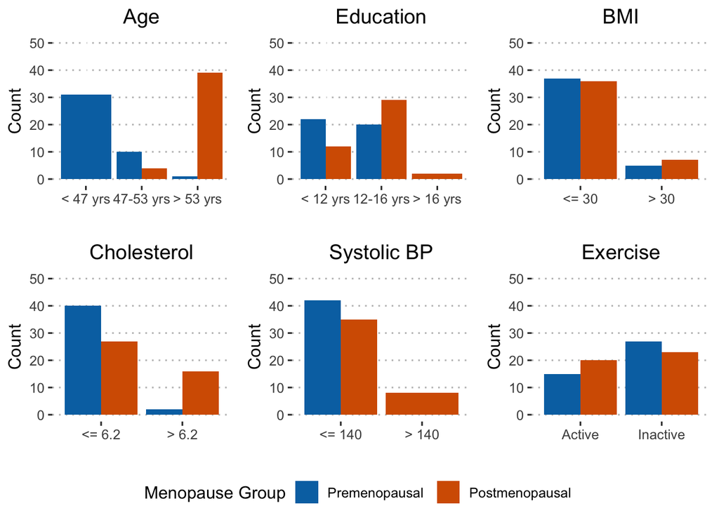

```r
dat <- cleaned_data_df %>%
  select(id, group_var, all_of(x_vars)) %>%
  convert_as_factor(!!!syms(c("id", "group_var", x_vars)))

plot_bar <- function(var, title, labels) {
  ggplot(dat, aes_string(x = var)) +
    geom_bar(aes(fill = group_var), position = "dodge") +
    scale_fill_manual(name = "Menopause Group", values = c("#0072B2", "#D55E00"), labels = c("Premenopausal", "Postmenopausal")) +
    scale_x_discrete(labels = labels) +
    scale_y_continuous(breaks = seq(0, 50, by = 10), limits = c(0, 50)) +
    labs(x = "", y = "Count", title = title) +
    theme_pubclean() +
    theme(plot.title = element_text(hjust = 0.5))
}

age_p <- plot_bar("Age_coded", "Age", c("< 47 yrs", "47-53 yrs", "> 53 yrs"))
edu_p <- plot_bar("Edu_coded", "Education", c("< 12 yrs", "12-16 yrs", "> 16 yrs"))
bmi_p <- plot_bar("BMI_coded", "BMI", c("<= 30", "> 30"))
chol_p <- plot_bar("Chol_coded", "Cholesterol", c("<= 6.2", "> 6.2"))
bp_p <- plot_bar("Systolic_coded", "Systolic BP", c("<= 140", "> 140"))
exercise_p <- plot_bar("Exercise_coded", "Exercise", c("Active", "Inactive"))

p_vrf2 <- ggarrange(age_p, edu_p, bmi_p, chol_p, bp_p, exercise_p,
                    ncol = 3, nrow = 2, common.legend = TRUE, legend = "bottom")
p_vrf2
```

### 3.1.1 Save Output

```r
# # Save plots
# plots <- list(
#   p_meno_cs_age_raw = p_meno_cs_age_raw,
#   p_meno_cs_acc_raw = p_meno_cs_acc_raw,
#   p_meno_cr_age_raw = p_meno_cr_age_raw,
#   p_meno_cr_acc_raw = p_meno_cr_acc_raw,
#   p_CAIDE_meno = p_CAIDE_meno,
#   p_vrf2 = p_vrf2
# )

# lapply(names(plots), function(n) {
#   ggsave(here("script2_outputs", sprintf("%s.jpeg", n)), plots[[n]], width = 8, height = 8, dpi = 700)
# })

# #Save model objects
# save(list = c(
#   "cleaned_data_df", "meno_cs_acc", "meno_cr_acc",
#   "cs_acc_CAIDE_pre", "cs_acc_CAIDE_post",
#   "cr_acc_CAIDE_pre", "cr_acc_CAIDE_post",
#   "lmm_CAIDE_cs_pre", "lmm_CAIDE_cs_post",
#   "lmm_CAIDE_cr_pre", "lmm_CAIDE_cr_post"
# ), file = here("script2_outputs", "supplemental_objects_Jan13_2025"))
```